# ESM 260: Applied Marine Ecology

Problem Set 4

Chase Brewster

3/03/2020

#Load Packages & Read in Data

```r
library(tidyverse)
library(wesanderson)

climate <- read_csv("climate.csv")
crab <- read_csv("crab.csv")
nuclear <- read_csv("nuclear.csv")
upwell <- read_csv("upwell.csv")
```

#1. Climate Change

First, there is growing pressure in Congress to relax environmental regulations affecting carbon dioxide emissions. You have been asked to provide evidence for changes in marine communities that may be due to climatic changes, such as increases in temperature. Your have data from a coastal site in Northern California that had been previously surveyed in 1955. During the ensuing 65 years there have been substantial changes in the abundances of several species. To help interpret the changes, you can look at the following information for all species: 1) the mode of development (i.e., planktonic larvae vs. non-planktonic larvae), 2) the geographic range (i.e., does the species range occur primarily North or South of the site, or is it Cosmopolitan - both north and south), and 3) the trophic level (i.e., predator, filter feeder, scavenger). What are the patterns of change? Try grouping the species by categories and see if anything emerges.

```r
##going to start by filtering for different qualities of the species and see if anything emerges

climate_explore <- climate %>%
  filter(trophic == "scavenger")

##going to run a linear model to see if any species category is significant

climate_lm <- lm(density ~ development+range+trophic, data = climate)

summary(climate_lm)
```

```
##
## Call:
## lm(formula = density ~ development + range + trophic, data = climate)
##
## Residuals:
##    Min     1Q Median     3Q    Max
## -48.52 -17.65   0.08  13.74  57.41
##
## Coefficients:
##                       Estimate Std. Error t value Pr(>|t|)
## (Intercept)             12.611     14.973   0.842 0.413791
## developmentplanktonic   20.268     15.523   1.306 0.212713
## rangeNorthern          -91.284     19.617  -4.653 0.000373 ***
## rangeSouthern           56.446     18.338   3.078 0.008181 **
## trophicpredator         -2.011     17.221  -0.117 0.908714
## trophicscavenger       -23.802     18.378  -1.295 0.216234
## ---
## Signif. codes:  0 '***' 0.001 '**' 0.01 '*' 0.05 '.' 0.1 ' ' 1
##
## Residual standard error: 31.61 on 14 degrees of freedom
## Multiple R-squared:  0.8093, Adjusted R-squared:  0.7412
## F-statistic: 11.88 on 5 and 14 DF,  p-value: 0.0001241
```

- there does not seem to be any patterns in planktonic vs. non-planktonic
- Northern species have all decreased in density (significant)
- Southern species have all increased in density (significant)
- there is no pattern for cosmopolitan
- there does not seem to be a pattern for predators
- there does not seem to be a pattern for filter feeders
- there does not seem to be a pattern for scavengers (all but 1 increase, but they are all southern & cosmo)

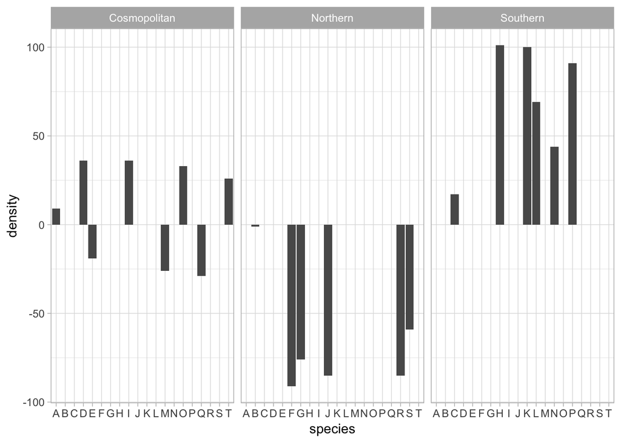

```r
##Now going to make graphs for each species category

climate_graph_range <- ggplot(climate, aes(x = species, y = density)) +
  geom_col() +
  facet_wrap(~range) +
  theme_light()

climate_graph_range
```

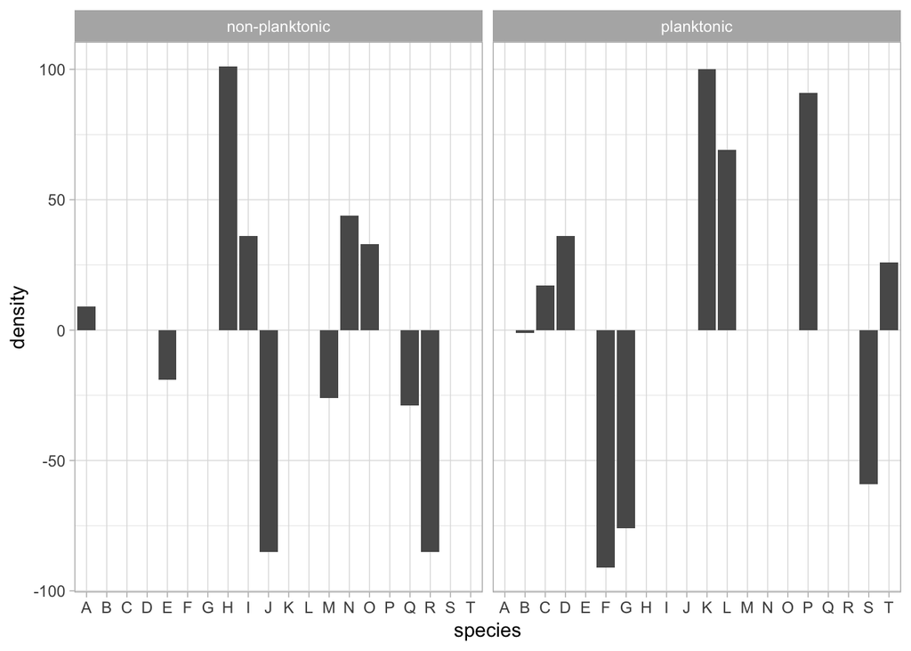

```r
climate_graph_development <- ggplot(climate, aes(x = species, y = density)) +
  geom_col() +
  facet_wrap(~development) +
  theme_light()

climate_graph_development
```

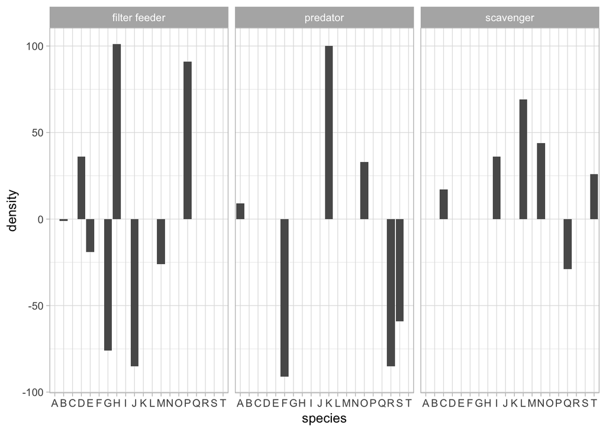

```r
climate_graph_trophic <- ggplot(climate, aes(x = species, y = density)) +
  geom_col() +
  facet_wrap(~trophic) +
  theme_light()

climate_graph_trophic
```

***

#2. Nuclear Power Plant

Second, El Diablo nuclear power plant is up for a renewal of its operating permit. One issue of concern is whether the plant has been altering the marine community near its discharge point (Diablo Cove). A monitoring program, which started ten years before the plant became operational in 2010, followed the abundance of 3 species of invertebrates at the discharge point and at two sites (Hyperion Bay & Noway Bay) that appeared to be at least superficially similar to the discharge point. You now also have ten years of monitoring data from the sites after the plant became operational. Are there any detectable impacts of the plant on these species? Which site(s) did you use as a control? Why?

```r
#diablo is the operating location
#became operational in 2010
#3 species

#create datasets for each species

nuclear_a <- nuclear %>%
  filter(species == "A")

nuclear_b <- nuclear %>%
  filter(species == "B")

nuclear_c <- nuclear %>%
  filter(species == "C")
```

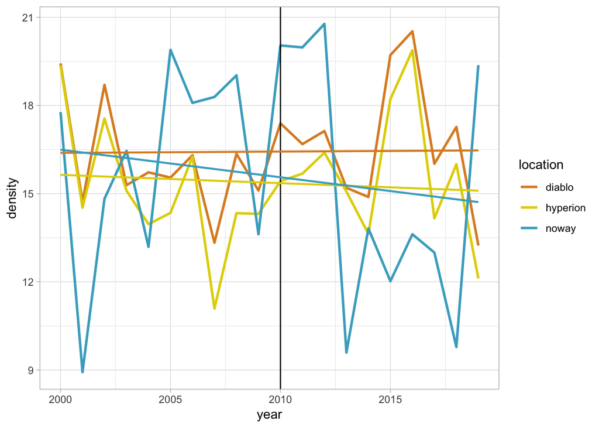

```r
#Species A
nuclear_a <- nuclear_a %>%
  group_by(location)

nuc_a_graph <- ggplot(nuclear_a, aes(x = year, y = density)) +
  geom_line(aes(color = location), size = 1) +
  theme_light() +
  scale_color_manual(values=wes_palette(n=3, name="FantasticFox1")) +
  geom_vline(xintercept = 2010) +
  geom_smooth(method = "lm", formula = y ~ x, aes(color = location), se = FALSE, size = 0.8)

nuc_a_graph
```

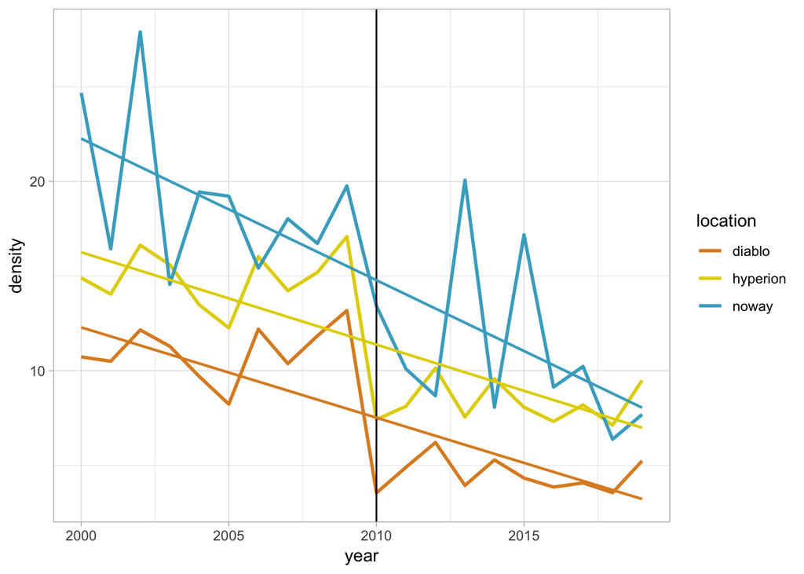

```r
#Species B
nuclear_b <- nuclear_b %>%
  group_by(location)

nuc_b_graph <- ggplot(nuclear_b, aes(x = year, y = density)) +
  geom_line(aes(color = location), size = 1) +
  theme_light() +
  scale_color_manual(values=wes_palette(n=3, name="FantasticFox1")) +
  geom_vline(xintercept = 2010) +
  geom_smooth(method = "lm", formula = y ~ x, aes(color = location), se = FALSE, size = 0.8)

nuc_b_graph
```

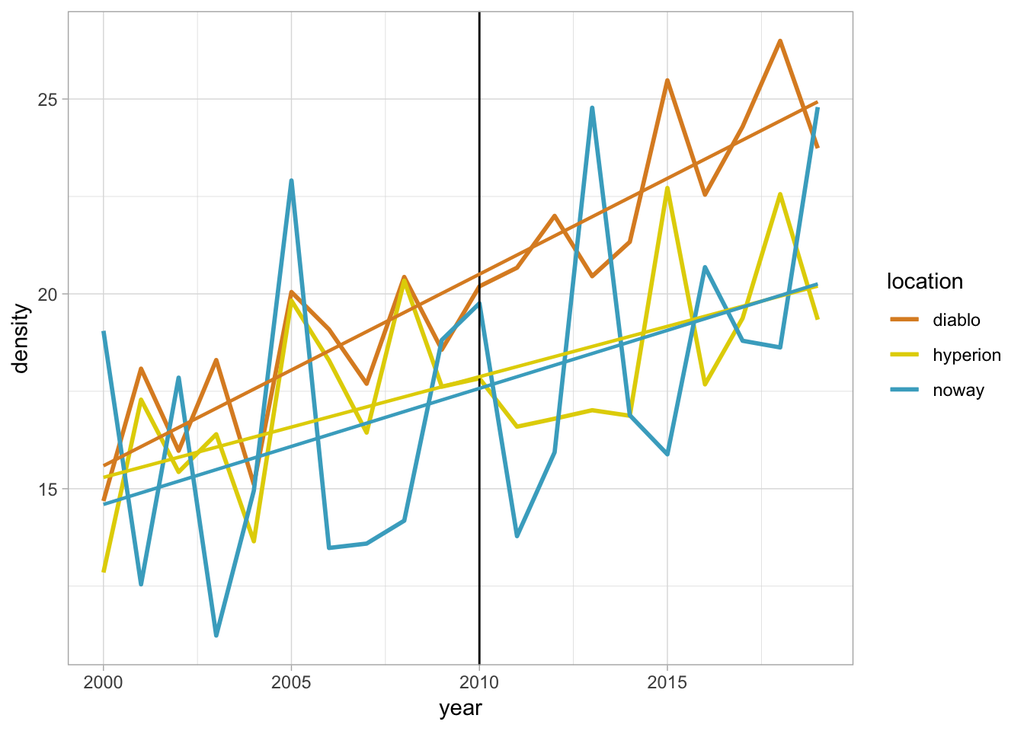

```r
#Species C
nuclear_c <- nuclear_c %>%
  group_by(location)

nuc_c_graph <- ggplot(nuclear_c, aes(x = year, y = density)) +
  geom_line(aes(color = location), size = 1) +
  theme_light() +
  scale_color_manual(values=wes_palette(n=3, name="FantasticFox1")) +
  geom_vline(xintercept = 2010) +
  geom_smooth(method = "lm", formula = y ~ x, aes(color = location), se = FALSE, size = 0.8)

nuc_c_graph
```

- there is no discernable trend for pre-2010 and post-2010 for Species A
- there is no discernable trend for pre-2010 and post-2010 for Species B
- there appears be a slightly greater increase for Species C post-2010 relative to the control
- Hyperion should serve as the control, relative to noway, as noway is highly variable and hyperion densities are closely aligned to diablo densities pre-2010

#3. Fisheries and Invasive Species

Finally, you have been asked to make recommendations regarding 2 key species of interest. One species is a crab (Cancer cancer). There is a great deal of interest in developing fisheries for Cancer cancer in both Oregon and California. The other species is a barnacle (Barnacle bill). Barnacle bill invaded the US West Coast possibly from Japan earlier in the century. It has become a nuisance species and regularly fouls pipes, ships etc. There is a great deal of interest in learning more about the dynamics of this species in an effort to eliminate it.